# weekend homework

hypothesis testing

# 1.1 Hypothesis testing - practical

## Load Packages

```r
library(tidyverse)
library(janitor)
library(infer)
```

## Read in Sleep Data

```r
sleep <- ggplot2::msleep %>%
  clean_names()
```

## Question 1.

### Explore the dataset and familiarise yourself with it.

```r
# dimensions of data
dim(sleep)

# glimpse whole data set
glimpse(sleep)
```

[output not shown]

## Question 2.

### Jabberwockies sleep for around 7 hours a night, on average. Perform an appropriate statistical test to determine whether the mean sleep_total in the sampled population of animal types differs from the typical value for jabberwockies.

### Hypotheses

*Null*: There is no difference in mean sleep total and jabberwockies mean sleep.

$$H_0: \mu_{sleep\ total} = 7$$

*Alternative*: There is a statistically significant difference in mean sleep total and mean jabberwockies sleep.

$$H_A: \mu_{sleep\ total} \ne 7$$
### Alpha level

For the purposes of this hypothesis test, *alpha = 0.05*

### Calculate observed statistic

```r
obs_stat <- sleep %>%
  summarise(mean_sleep_total = mean(sleep_total))

obs_stat
```

| mean_sleep_total |
| --- |
| 10.43373 |

### Create Null Sampling Distribution

```r
null_dist <- sleep %>%
  specify(response = sleep_total) %>%
  hypothesise(null = "point", mu = 7) %>%
  generate(reps = 10000, type = "bootstrap") %>%
  calculate(stat = "mean")

null_dist
```

```
Response: sleep_total (numeric)
Null Hypothesis: point
```

| replicate | stat |
| --- | --- |
| 1 | 7.691566 |
| 2 | 7.308434 |
| 3 | 7.179518 |
| 4 | 6.907229 |
| 5 | 6.944578 |
| 6 | 7.457831 |
| 7 | 7.771084 |
| 8 | 6.377108 |
| 9 | 6.321687 |
| 10 | 6.467470 |

[output cut: 990 more lines]

### Visualise Observed Stat on Null Sampling Distribution

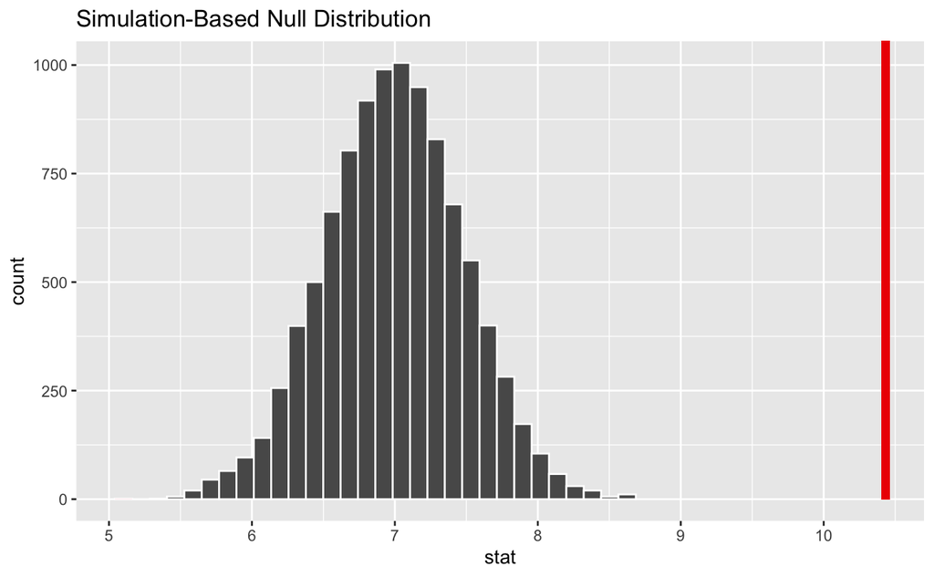

```r
null_dist %>%
  visualise(bins = 30) +
  shade_p_value(obs_stat = obs_stat$mean_sleep_total, direction = "both")
```

*Interpretation*

Visually, it appears that there may be a statistically significant difference in the mean sleep total for the animals in our data set and the mean sleep for jabberwockies. This is due to the extreme right location of our observed statistic (red line) in relation to our normal sampling null distribution.

### Calculate p-value

```r
null_dist %>%
  get_p_value(obs_stat = obs_stat, direction = "both")
```

| p_value |
| --- |
| 0 |

*Outcome*

Since our p-value of 0 < 0.05 (alpha), we reject the null hypothesis that the difference in mean sleep total and mean jabberwockie sleep is zero. It would appear that a more suitable assumption is that there is a statistically significant difference in the mean sleep totals of animals v jabberwockies.

## Question 3.

## Perform an appropriate statistical test to determine whether omnivores sleep for significantly longer than herbivores, on average.

### Filter Sleep Data for Omnivores and Herbivores

```r
omni_herbi_sleep <- sleep %>%
  filter(vore %in% c("omni", "herbi"))
```

### Hypotheses

H0: The mean sleep for omnivores <= mean sleep for herbivores

$$H_0: \mu_{omnivore\ sleep} =\ \mu_{herbivore\ sleep}$$

Ha: The mean sleep for omnivores > mean sleep for herbivores

$$H_A: \mu_{omnivore\ sleep} >\ \mu_{herbivore\ sleep}$$

### Alpha Level

For this hypothesis test alpha = 0.05

### Boxplot

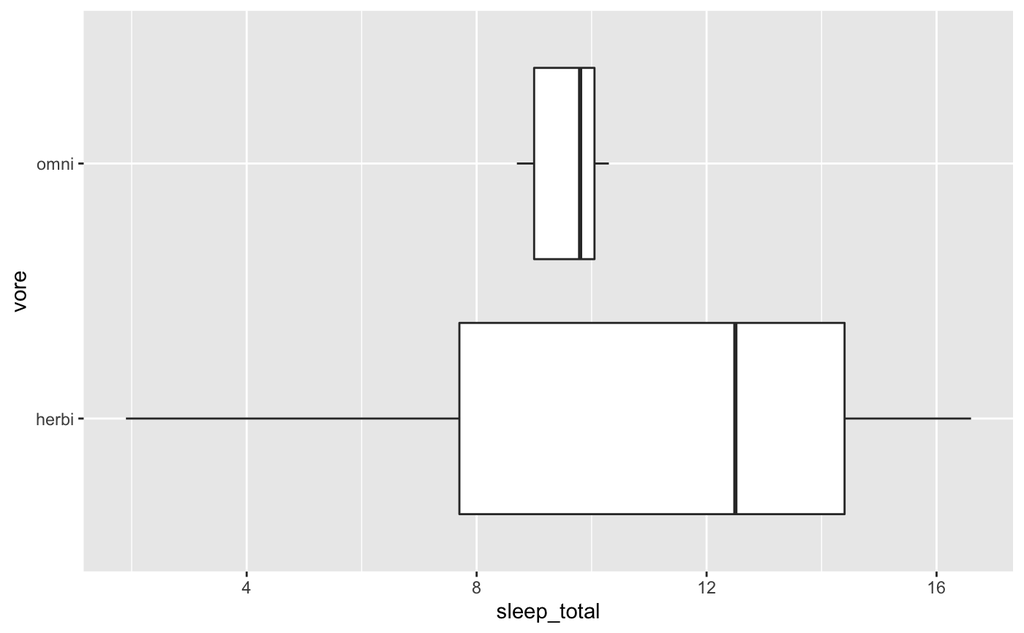

```r
omni_herbi_sleep %>%
  ggplot(aes(x = sleep_total, y = vore)) +
  geom_boxplot()
```

### Calculate Observed Statistic

```r
observed_stat <- omni_herbi_sleep %>%
  specify(sleep_total~vore) %>%
  calculate(stat = "diff in means", order = c ("omni", "herbi"))

observed_stat
```

```
Response: sleep_total (numeric)
Explanatory: vore (factor)
```

| stat |
| --- |
| 1.415625 |

### Create Null Sampling Distribution

```r
null_distribution <- omni_herbi_sleep %>%
  specify(sleep_total~vore) %>%
  hypothesise(null = "independence") %>%
  generate(reps = 10000, type = "permute") %>%
  calculate(stat = "diff in means", order = c("omni", "herbi"))

null_distribution
```

```
Response: sleep_total (numeric)
Explanatory: vore (factor)
Null Hypothesis: independence
```

| replicate | stat |
| --- | --- |
| 1 | -0.981250 |
| 2 | -0.209375 |
| 3 | -0.266250 |
| 4 | 0.578750 |
| 5 | -2.630625 |
| 6 | -2.078125 |
| 7 | 0.481250 |
| 8 | 1.058125 |
| 9 | 0.660000 |
| 10 | -1.005625 |

[output cut: 990 more lines]

### Visualise Null Sampling Distribution and Observed Statistic

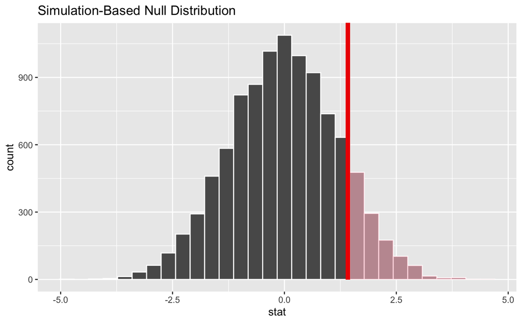

```r
null_distribution %>%
  visualise(bins = 30) +
  shade_p_value(obs_stat = observed_stat, direction = "right")
```

### Calculate p-value

```r
null_distribution %>%
  get_p_value(obs_stat = observed_stat, direction = "right")
```

| p_value |
| --- |
| 0.1232 |

**Outcome**

Since the p-value of 0.1232 > 0.05, we fail to reject the null hypothesis and say that there is no statistically significant difference in mean sleep between omnivores and herbivores. We don’t have a enough evidence to reject the null and say that assumption holds for now.

## Question 4.

## Perform an appropriate statistical test to determine whether the proportion of domesticated animal types in the population of animal types is greater than 5%.

### Clean Data

```r
sleep_tidy <- sleep %>%
  filter(!is.na(conservation))

sleep_tidy_prop <- sleep_tidy %>%
  mutate(domesticated_flag = if_else(conservation == "domesticated", "domesticated",
                                     "undomesticated"))
```

### Hypotheses

H0: Proportion domesticated animals types = 5%

Ha: Proportion domesticated animal types > 5%

### Observed Stat

```r
prop_observed_stat <- sleep_tidy_prop %>%
  specify(response = domesticated_flag, success = "domesticated") %>%
  calculate(stat = "prop")

prop_observed_stat
```

```
Response: domesticated_flag (factor)
```

| stat |
| --- |
| 0.1851852 |

### Create Null Sample Distribution

```r
prop_null_distribution <- sleep_tidy_prop %>%
  specify(response = domesticated_flag, success = "domesticated") %>%
  hypothesize(null = "point", p = 0.05) %>%
  generate(reps = 10000, type = "draw") %>%
  calculate(stat = "prop")

head(prop_null_distribution)
```

```
Response: domesticated_flag (factor)
Null Hypothesis: point
```

| replicate | stat |
| --- | --- |
| 1 | 0.03703704 |
| 2 | 0.05555556 |
| 3 | 0.05555556 |
| 4 | 0.07407407 |
| 5 | 0.09259259 |
| 6 | 0.01851852 |

### Visualise Null Sampling Distribution and Observed Statistic

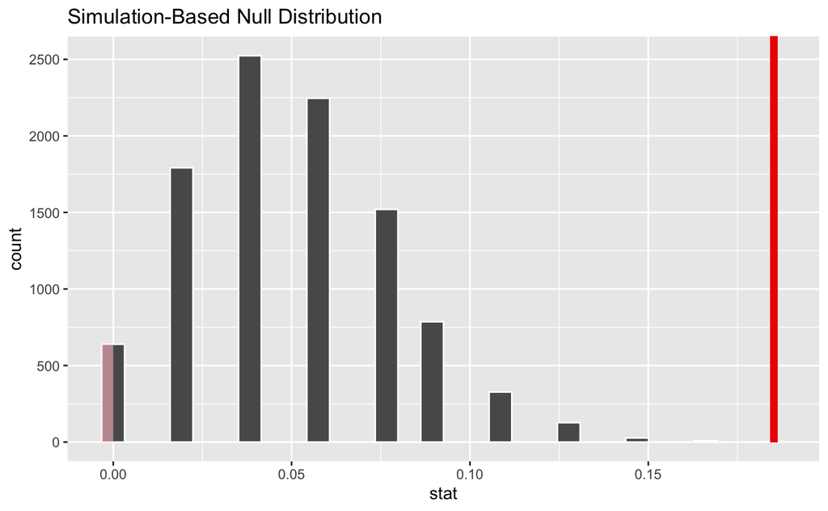

```r
prop_null_distribution %>%
  visualise(bins = 30) +
  shade_p_value(obs_stat = prop_observed_stat, direction = "both")
```

### Calculate p-value

```r
p_value <- prop_null_distribution %>%
  get_p_value(obs_stat = prop_observed_stat, direction = "right")

options(scipen = 999)
p_value
```

| p_value |
| --- |
| 0.0003 |

**Outcome**

Since the p-value of 0.0003 < 0.05, we reject the null hypothesis and say there is statistical significance to say that they proportion of domesticated animal types is greater than 5%. We are not accepting the alternative, rather saying we reject the null and the alternative is a more suitable assumption for the time being.

# 1.2 Hypothesis testing - Defining the Hypothesis

## Question 1

### Solutions

**Test Used**

I would carry out a one sample proportion test.

**Hypotheses**

H0: The proportion of residents that have heard of the coffee shop is less than 40%.

$$H_0: \pi_{residents} <\ 40\%$$

Ha: The proportion of residents that have heard of the coffee shop is greater than or equal to 40%.

$$H_0: \pi_{residents} > or = 40\%$$
**Method**

I would use a simulation to carry out this test with null = point and p = 0.4.

## Question 2

### Solutions

**Test Used**

I would use a two sample proportion test.

**Hypotheses**

H0: There is no difference in proportions between group A and group B.

$$H_0: \pi_{group\ A} - \pi_{group\ B} = 0$$

Ha: the proportion of users clicking on the banner in group B is greater than the proportions of users clicking on the banner in group A.

$$H_0: \pi_{group\ B} - \pi_{group\ A}> 0$$

**Method**

I would use permutation to switch the users CTR between group A and group B.

## Question 3

### Solutions

_Test Used__

I would use a one sample mean test.

**Hypotheses**

Ho: There is no difference in mean width from 145mm

$$H_0: \mu_{width} = 145$$
Ha: There is a significant difference in mean width from 145mm

$$H_0: \mu_{width} \ne 145$$

**Method**

I would use the bootstrap method to create a null sample distribution.

# 1.3 Hypothesis Testing - Interpreting the results

## Question 1.

### Coffee shop problem. Significance level: 0.05, calculated p-value: 0.07

**Interpretation**

Since the p-value of 0.07 > 0.05, we fail to reject the null hypothesis and say that we have insufficient evidence to say that a greater proportion than 40% residents have heard of the coffee shop.

## Question 2.

### Website company problem. Significance level: 0.01, p-value: 0.006

**Interpretation**

Since the p-value of 0.006 < 0 .01, we reject the null hypothesis and say there is a statistical significance in CTR between the groups. It appears that there is a greater CTR when the banner is placed at the top of the screen. It should be said that this is only our currently working assumption until something else comes along.

## Question 3.

### Manufacturing company problem. Significance level: 0.05, p-value: 0.55

**Interpretation**

Since the p-value of 0.55 > 0.05, we fail to reject the null hypothesis and say that there appears to be no statistically significant difference in mean width from 145mm. Again, it doesn’t mean this is the conclusion, this is just our current working assumption based on the evidence.